# Clustering Homework

Aaron

July 18, 2016

### Homework Assignment:

- Using the mtcars data set
- Create a kmeans object from the first, second, and third columns
- What is the size of each cluster?
- What are the centers of each cluster?
- What is the average disp, wt, and qsec of each cluster?
- Describe each cluster in English.

```r
data("mtcars")

library(dplyr)
library(knitr)
library(ggplot2)
library(GGally)
```

First we need to determine how many clusters to create.

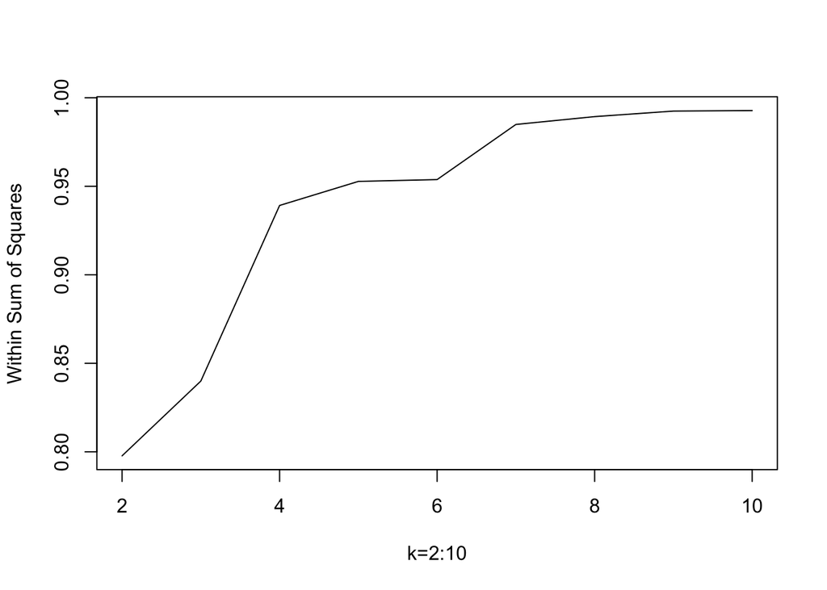

```r
set.seed(1234)
wi = 0

for (i in 2:10) {
  z = kmeans(mtcars[,1:3], i)
  wi[i-1] = z$betweenss / z$totss
}
# report the list of within cluster sum of squares
plot(2:10, wi, type='l', xlab="k=2:10", ylab="Within Sum of Squares")
```

### Create a kmeans object from the first, second, and third columns

What is the size of each cluster?

```r
r = kmeans(mtcars[,1:3], centers =4, nstart=20)

r$size
```

```
## [1]  8  4  9 11
```

The size of those 4 clusters are 8, 4,9 and 11.

### What are the centers of each cluster?

```r
r$centers
```

```
##        mpg      cyl      disp
## 1 20.50000 5.500000 164.08750
## 2 13.67500 8.000000 443.00000
## 3 27.34444 4.000000  96.55556
## 4 16.19091 7.818182 311.76364
```

### What is the average disp, wt, and qsec of each cluster?

For this task, we should derive the cluster labels as an aggregation dimension for the data set.

```r
mtcars %>%
    mutate(clusters = r$cluster) %>%
    group_by(clusters) %>%
    summarise_each(funs(mean), c(disp, wt, qsec)) %>% kable()
```

| clusters | disp | wt | qsec |
| --- | --- | --- | --- |
| 1 | 164.08750 | 3.118125 | 18.66250 |
| 2 | 443.00000 | 4.966000 | 17.56750 |
| 3 | 96.55556 | 2.089222 | 18.62333 |
| 4 | 311.76364 | 3.576364 | 16.72545 |

### Describe each cluster in English.

Cluster 1: cars that have medium disp, medium mpg and cyl.

Cluster 2: cars that have highest disp, lowest mpg.

Cluster 3: car that have lowest disp, highest mpg.

Visually describe all the clusters:

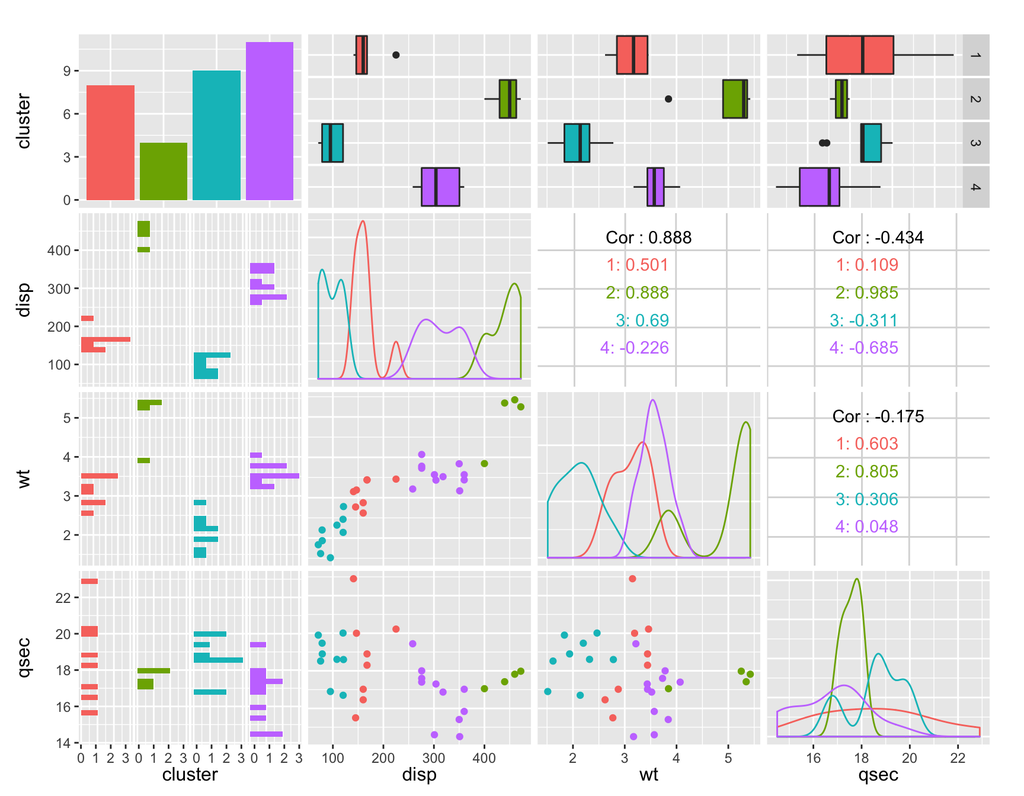

```r
mtcars %>%
    mutate(cluster = as.factor(r$cluster)) %>%
    select(c(cluster, disp, wt, qsec)) %>%
    ggpairs(mapping = aes(color = cluster))
```

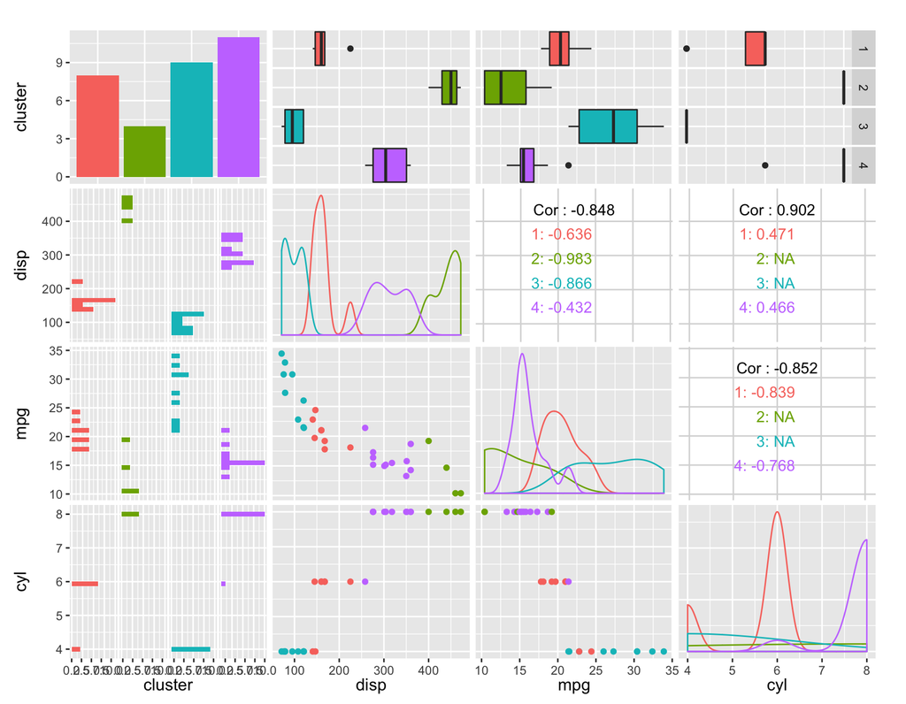

```r
mtcars %>%
    mutate(cluster = as.factor(r$cluster)) %>%
    select(c(cluster, disp, mpg, cyl, disp)) %>%
    ggpairs(mapping = aes(color = cluster))
```